# STAT-847-Final-Project

Pranjal Gaur

20/04/2022

## Reading Data

Reading the gamelog data and checking dimensions

```r
match_data= read.csv("Gamelog T20I Stat 847.csv")
head(match_data)
```

```
##   Format MatchNo TeamBowling TeamBatting Inning Over Ball Bowler BowlerID
## 1   T20I      33         AUS          BD      1    0    1  B Lee       17
## 2   T20I      33         AUS          BD      1    0    2  B Lee       17
## 3   T20I      33         AUS          BD      1    0    3  B Lee       17
## 4   T20I      33         AUS          BD      1    0    4  B Lee       17
## 5   T20I      33         AUS          BD      1    0    4  B Lee       17
## 6   T20I      33         AUS          BD      1    0    5  B Lee       17
##       Batsman BatsmanID Fielder FielderID Outcome NumOutcome BallType
## 1 Tamim Iqbal      1041                NA      no          0      run
## 2 Tamim Iqbal      1041                NA      no          0      run
## 3 Tamim Iqbal      1041                NA      no          0      run
## 4 Tamim Iqbal      1041                NA       1          1     wide
## 5 Tamim Iqbal      1041                NA      no          0      run
## 6 Tamim Iqbal      1041                NA      no          0      run
##   NumBallType  Notes
```

[output cut: 20 more lines]

```r
dim(match_data)
```

```
## [1] 168966     21
```

```r
data1=match_data
```

## Data Cleaning

Analyzing the data and filtering out match_ids with more than 1 match data, missing leagues, abnormal wicket count(like 24), more than two teams in a game, etc.

```r
sort(unique(match_data$MatchNo))
```

```
##   [1]      1      2      3      4      5      6      7      8     10     11
##  [11]     12     13     14     15     16     18     20     23     24     25
##  [21]     28     29     30     31     32     33     34     35     36     37
##  [31]     38     39     40     41     42     43     44     45     46     47
##  [41]     48     49     50     51     52     53     54     55     56     57
##  [51]     69     72     73     76     77     78     79     80     81     82
##  [61]     83     84     85     86     87     88     89     92     93     95
##  [71]     97     99    100    103    104    105    106    107    109    111
##  [81]    112    113    114    115    116    117    118    119    120    121
##  [91]    122    123    124    125    126    127    131    134    144    145
## [101]    146    147    148    149    150    151    154    155    156    157
## [111]    158    159    161    163    164    165    166    167    168    169
## [121]    170    171    172    173    174    175    176    177    178    179
## [131]    180    181    182    183    184    185    186    187    188    189
## [141]    190    191    192    193    194    195    196    197    198    199
```

[output cut: 54 more lines]

```r
summary(match_data$NumOutcome)
```

```
##     Min.  1st Qu.   Median     Mean  3rd Qu.     Max.     NA's
##   -1.000    0.000    1.000    1.238    1.000 2015.000       16
```

As we see there exists a match with 2015 runs which is an anomaly, so we filter it out.

```r
rowsToExclude=which(data1$NumOutcome==2015)
data1=match_data[-rowsToExclude,]
```

Similarly, we exclude rows containing NA, considering these to be case of MCAR. Also, we remove rows containing empty fields in Format.

```r
data1=data1[!(is.na(data1$MatchNo)),]
data1=data1[!(is.na(data1$NumOutcome)),]
data1=data1[-which(data1$Format ==" "),]
```

Finally, we proceed to find and remove data for matches with abnormal runs or single match id containing duplicate or multiple matches data.

```r
match_ids_faulty= c()
match_ids_faulty = c(match_ids_faulty, unique(data1[which(data1$Wickets>9), 2]))

faulty_matches = c(191, 440, 200903, 200906, 200933,200938,200947,200948,201103,
                   201109, 201112,201128,201131,201211,201228,201258
                   ,201273,201275,201536,201554)
match_ids_faulty = c(match_ids_faulty, faulty_matches)
data2=data1[-which(data1$MatchNo %in% match_ids_faulty),]

total_runs_per_match_clean_data = ddply(data2,
                                        .(MatchNo),
                                        summarize,
                                        total_runs = sum(NumOutcome[which(
                                          NumOutcome >=0 & NumOutcome<=7)])
)
summary(total_runs_per_match_clean_data)
```

```
##     MatchNo           total_runs
##  Min.   :     1.0   Min.   : 80.0
##  1st Qu.:   212.8   1st Qu.:262.0
##  Median :200915.5   Median :299.0
##  Mean   :103850.3   Mean   :309.2
##  3rd Qu.:201319.2   3rd Qu.:336.0
##  Max.   :201560.0   Max.   :786.0
```

```r
matches_with_redundant_records = total_runs_per_match_clean_data[which(
  total_runs_per_match_clean_data$total_runs > 465),1]
data2=data2[-which(data2$MatchNo %in% matches_with_redundant_records),]

head(data2)
```

```
##   Format MatchNo TeamBowling TeamBatting Inning Over Ball Bowler BowlerID
## 1   T20I      33         AUS          BD      1    0    1  B Lee       17
## 2   T20I      33         AUS          BD      1    0    2  B Lee       17
## 3   T20I      33         AUS          BD      1    0    3  B Lee       17
## 4   T20I      33         AUS          BD      1    0    4  B Lee       17
## 5   T20I      33         AUS          BD      1    0    4  B Lee       17
## 6   T20I      33         AUS          BD      1    0    5  B Lee       17
##       Batsman BatsmanID Fielder FielderID Outcome NumOutcome BallType
## 1 Tamim Iqbal      1041                NA      no          0      run
## 2 Tamim Iqbal      1041                NA      no          0      run
## 3 Tamim Iqbal      1041                NA      no          0      run
## 4 Tamim Iqbal      1041                NA       1          1     wide
## 5 Tamim Iqbal      1041                NA      no          0      run
## 6 Tamim Iqbal      1041                NA      no          0      run
##   NumBallType  Notes
```

[output cut: 20 more lines]

## Part 1. Answer

For first ggplot, we slice the data to find total sixes hit in each over across two innings. This analysis can help to understand the difference in risk approach of batsmen across innings and different overs.

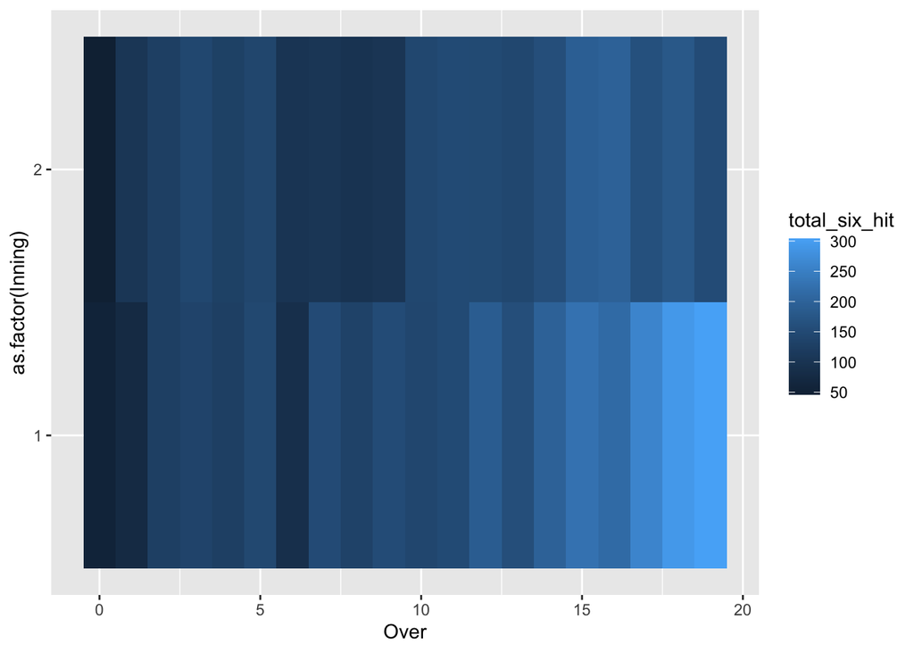

```r
#total sixes hit in each over in an inning
df_split_1=ddply(data2,
               .(Over,Inning),
               summarize,
               total_six_hit = length(which(NumOutcome == 6))
               )

ggplot(df_split_1,aes(x=Over,y=as.factor(Inning), fill=total_six_hit)
       ,xlab="Over"
       ,ylab="Inning") +  geom_tile()
```

For second ggplot, we slice the data to find total wickets taken in each over across two formats - namely, IPL and T20 Internationals. This analysis again provides insights into how bowler-friendly pitches are present in IPL vs T20I based on how many wickets fall in each over across two leagues.

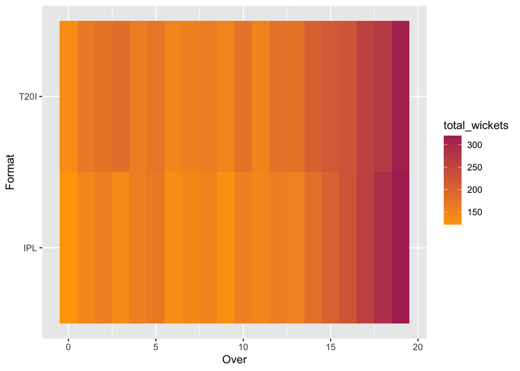

```r
#total wickets taken in each over across format
df_split_2=ddply(data2,
                 .(Over,Format),
                 summarize,
                 total_wickets = length(which(NumOutcome == -1))
)

ggplot(df_split_2,aes(x=Over,y=Format, fill=total_wickets)
       ,xlab="Over"
       ,ylab="Inning") +  geom_tile() + scale_fill_gradient(low = "orange",
                                                            high = "maroon")
```

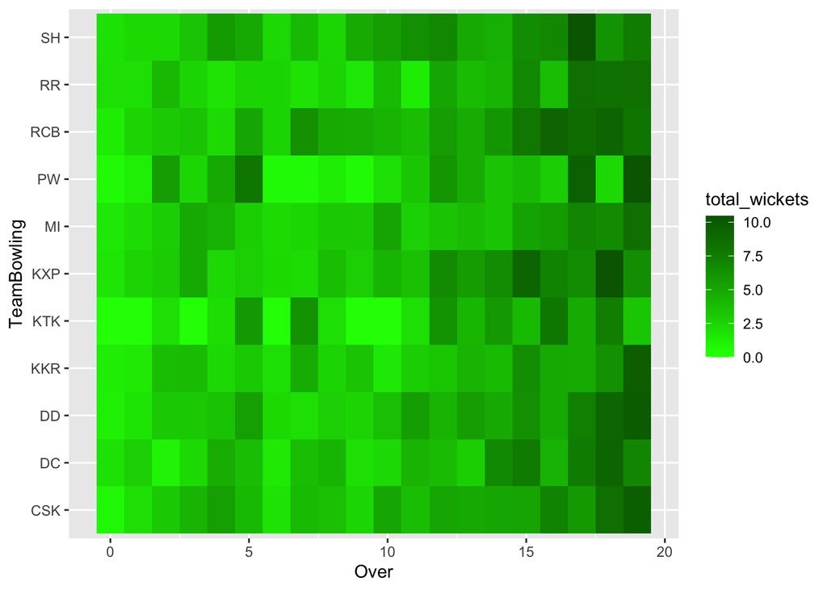

```r
# Analysis of percentage of total sixes hit in each over by an IPL team

 #only including IPL teams
df_split_3=ddply(subset(data2, Format == "IPL" & !(TeamBowling %in% c("IND"))),
                 .(TeamBowling,Over),
                 summarize,
                 total_wickets = mean(NumOutcome == 6)*100
)

ggplot(df_split_3,aes(y=TeamBowling,x=Over, fill=total_wickets)
       ,xlab="Over"
       ,ylab="Team") + geom_tile() +scale_fill_gradient(low = "green",
                                                        high = "dark green")
```

As we see above, maximum of sixes are preferred to hit in final 3 overs, which makes sense as teams are not afraid to take more risk towards final 3 overs of the innings.

## Part 2. Answer

Generating highlights of second inning data based on sum of emotional valence and resource usage difference between subsequent balls calculated for each ball to assign a score.

(Please follow comments for code explanation)

```r
DLS = read.csv("DLS_T20.csv")[,-1]
result_highlights = data.frame()
match_ids = unique(data2$MatchNo)

for(match in match_ids) #repeat for each match
{
  resource_used_vector = c() #vector that contains resource usage difference for each ball
  resource_left_vector = c() #vector that contains resource left after each ball
  runs_needed_to_keep_up=c() #vector that contains runs needed after each ball

  data_first_inning=subset(data2,MatchNo ==match & Inning==1) #first inning data
  target = by(data_first_inning$NumOutcome>=0 & data_first_inning$NumOutcome<=7,
              data_first_inning$Inning, sum) #target
  data_second_inning=subset(data2,MatchNo == match & Inning==2) #second inning data

  sample_text <- data_second_inning$FullNotes #capturing commentary/FullNotes data

  #performing sentiment analysis by using afinn method
  afinn_vector=get_sentiment(sample_text, method="afinn", lang="english")

  #for each ball bowled in second inning, calculate resource usage and resource left
  for(i in 1:nrow(data_second_inning))
  {
    resource_left = (1-(data_second_inning[i,7]/6))*DLS[data_second_inning[i,6]+1,
                                                    data_second_inning[i,21]+1]
    +data_second_inning[i,7]/6*DLS[data_second_inning[i,6]+2,
                                   data_second_inning[i,21]+1]
    resource_used = DLS[data_second_inning[i,6]+1,data_second_inning[i,21]+1] -
      resource_left
    runs_needed_to_keep_up = c(runs_needed_to_keep_up,
                               round(resource_used * target, 3))
     # round to 4 digits
    resource_used_vector = c(resource_used_vector, round(resource_used, 4))
    resource_left_vector = c(resource_left_vector, round(resource_left, 4))
  }
  #initializing vector to contain score for each ball
  ball_score=c(as.numeric(afinn_vector[1]))
  highlight_balls = data.frame(cbind(data_second_inning,ball_score[1]))
   #renaming column to -> Score
  colnames(highlight_balls)[dim(highlight_balls)[2]] = "Score"

  for(i in 2:length(afinn_vector)) #for each ball
  {
    #calculating emotional valence through sentiment analysis
    emotional_valence = abs(afinn_vector[i])
    #for each ball bowled in second inning, calc difference in resource usage and resource left
    resource_usage_difference = abs(resource_used_vector[i-1] - resource_used_vector[i])
    resource_left_difference = abs(resource_left_vector[i] - resource_left_vector[i-1])

    if(data_second_inning[i,15] == -1 ) #for wicket, assign higher score
      ball_score = c(ball_score, 2.5*(emotional_valence) + 100*resource_usage_difference)

    #for fours (num outcome = 5 included for four on a no-ball or wide), assign higher score
    else if(data_second_inning[i,15] >= 4  & data_second_inning[i,15] < 6)
      ball_score = c(ball_score, 1.5*(emotional_valence) + 100*resource_usage_difference)
    #for sixes (num outcome = 7 included for six on a no-ball or wide), assign higher score
    else if(data_second_inning[i,15] >= 6)
      ball_score = c(ball_score, 2.5*(emotional_valence) + 100*resource_usage_difference)
    else #assign lower score for other balls
      ball_score = c(ball_score, (emotional_valence + resource_usage_difference))
    highlight_balls[nrow(highlight_balls)+1,] = c(data_second_inning[i,], ball_score[i])

  }
  Final_highlight_balls = highlight_balls
  Final_highlight_balls[,22] = highlight_balls[,22]

  #sorting in decreasing order of score assigned to each ball
  Final_highlight_balls = Final_highlight_balls[order(-Final_highlight_balls$Score),]
  #taking top 20 balls with highest score in our highlights
  Final_highlight_balls = Final_highlight_balls[1:20,]
  #arranging rows in increasing order based on overs and balls
  Final_highlight_balls = Final_highlight_balls[order(Final_highlight_balls$Over,
                                                      Final_highlight_balls$Ball),]

  result_highlights = rbind(result_highlights,Final_highlight_balls)

}
```

Here, result_highlights is the dataframe containing 20 ball highlights/turning-points of each match provided in the dataset.

```r
result_highlights[which(result_highlights$MatchNo==161),]
```

```
##     Format MatchNo TeamBowling TeamBatting Inning Over Ball    Bowler BowlerID
## 119   T20I     161         AUS          BD      2    0    3   SW Tait       39
## 122   T20I     161         AUS          BD      2    0    6   SW Tait       39
## 125   T20I     161         AUS          BD      2    1    3 DP Nannes       66
## 138   T20I     161         AUS          BD      2    3    2 DP Nannes       66
## 141   T20I     161         AUS          BD      2    3    5 DP Nannes       66
## 149   T20I     161         AUS          BD      2    4    5   SW Tait       39
## 161   T20I     161         AUS          BD      2    6    5 MJ Clarke        5
## 169   T20I     161         AUS          BD      2    8    1 SPD Smith       46
## 178   T20I     161         AUS          BD      2    9    4 RJ Harris       52
## 180   T20I     161         AUS          BD      2    9    6 RJ Harris       52
## 184   T20I     161         AUS          BD      2   10    4 SPD Smith       46
## 188   T20I     161         AUS          BD      2   11    2 DJ Hussey       14
## 190   T20I     161         AUS          BD      2   11    4 DJ Hussey       14
## 197   T20I     161         AUS          BD      2   12    5 SPD Smith       46
```

[output cut: 90 more lines]

## Part 3. Answer

Scatter Plot

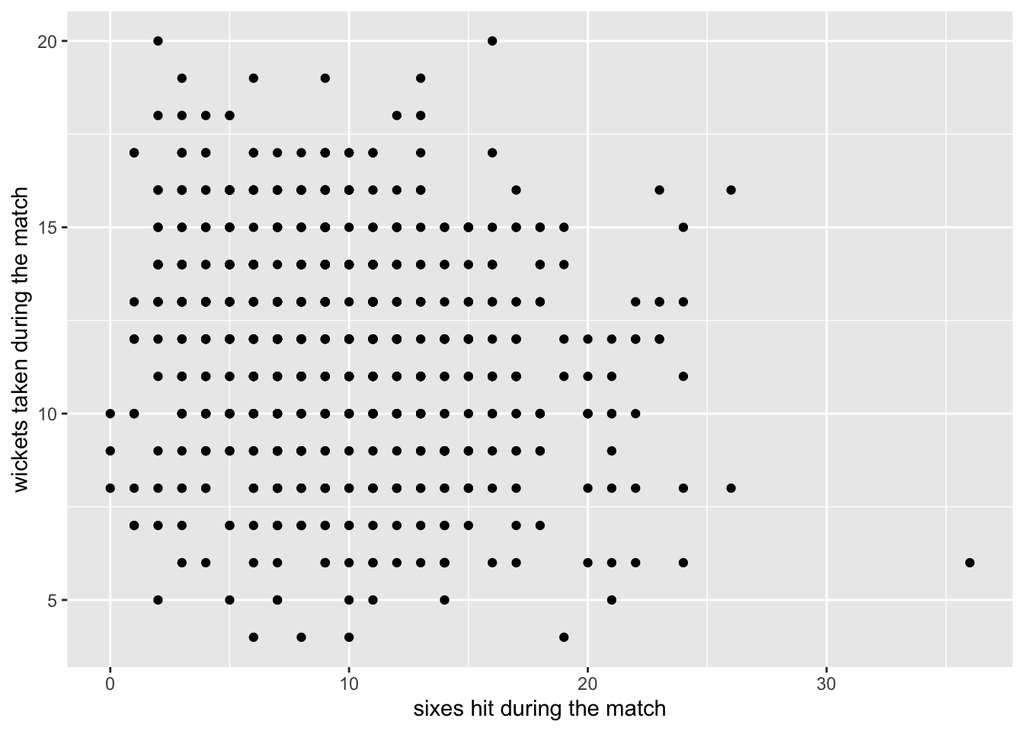

```r
cluster_df = data2
df_matches = ddply(cluster_df, "MatchNo", summarize,
                    total_wickets = length(which(NumOutcome == -1)),
                    total_six = length(which(NumOutcome == 6 | NumOutcome ==7)),
                    total_four = length(which(NumOutcome == 4 | NumOutcome ==5)),
                    total_runs = sum(pmax(NumOutcome, 0, na.rm=TRUE))
)

gr1 <- ggplot(df_matches, aes(x = total_six,  y = total_wickets)) +
  geom_point() +
  ylab("wickets taken during the match") +
  xlab("sixes hit during the match")
plot(gr1)
```

2D Contour Plot

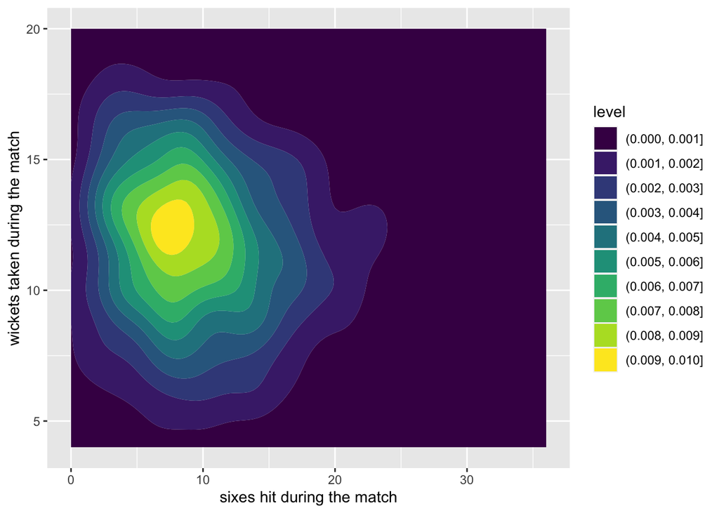

```r
gr2 <- ggplot(df_matches, aes(x = total_six,  y = total_wickets)) +
  geom_density_2d_filled() +
  ylab("wickets taken during the match") +
  xlab("sixes hit during the match")
plot(gr2)
```

Now, we proceed with K-means clustering. We look at within sum of squares distance before deciding on the number of clusters.

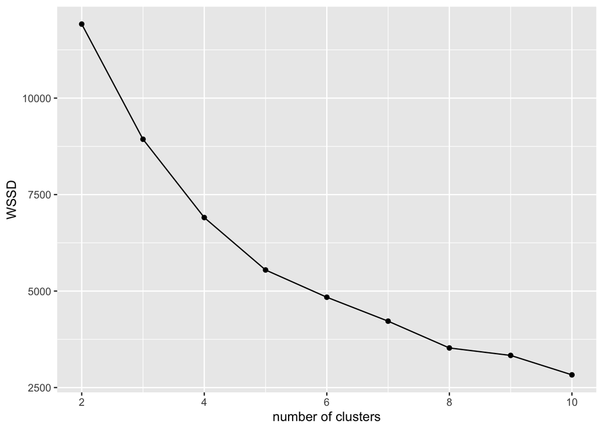

```r
df_shot_risk = subset(df_matches, select = c(total_six, total_wickets))
wssd <- rep(NA,9)
for(k in 2:10) {
  shot_clust <- kmeans(df_shot_risk, centers = k)
  wssd[k-1] <- shot_clust$tot.withinss
}

centers <- 2:10
dat <- data.frame(centers, wssd)
gr3 <- ggplot(dat, aes(x=centers, y=wssd)) +
  geom_line() +
  geom_point() +
  xlab("number of clusters") +
  ylab("WSSD")
plot(gr3)
```

From the elbow plot, either 5 or 6 clusters provides an ideal balance between parsimony and goodness-of-fit. We’ll try 5 clusters for our initial analysis. This is because this is the point where diminishing returns are no longer worth the additional cost.

```r
# We can take 5 clusters in our case as can be seen from elbow chart

shot_clust_5 <- kmeans(df_shot_risk, centers = 5)
shot_clust_5$centers
```

```
##   total_six total_wickets
## 1  9.404580     14.412214
## 2  4.132867     13.664336
## 3 19.875000     10.777778
## 4  6.709924      8.572519
## 5 13.061224     10.612245
```

The relative amounts of diffusion and the sizes of each of these clusters is as below:

```r
msd <- sqrt(shot_clust_5$withinss / shot_clust_5$size)
msd
```

```
## [1] 2.413856 2.791550 4.272521 2.951307 2.915297
```

```r
shot_clust_5$size
```

```
## [1] 131 143  72 131 147
```

## Part 4. Answer

```r
DLT = read.csv("DLS_T20.csv")[,-1]
dls_df = data.frame(subset(data2, Inning==1)) #First inning data filtered

dls_df$over2 = dls_df[,6] + dls_df[,7]/6 #reading overs column
dls_df$Nruns = pmax(dls_df[,15], 0) #reading runs column

dls_df_result = data.frame()

#function to calculate proportion of target achieved in each ball
func_calc_prop = function(match)
{
  df_temp = data.frame()
  df_temp = data.frame(subset(dls_df, MatchNo==match))
  target = sum(df_temp$Nruns) #target

  #using cumulative sum to calc prop of target achieved after each ball
  for(i in 1:nrow(df_temp))
  {
    df_temp$cum = cumsum(df_temp$Nruns)
    df_temp$prop[i] = df_temp$cum[i]/target
  }
  return(rbind(dls_df_result,df_temp))
}

for(match in match_ids) #calling above function
  dls_df_result = func_calc_prop(match)

head(dls_df_result)
```

```
##   Format MatchNo TeamBowling TeamBatting Inning Over Ball Bowler BowlerID
## 1   T20I      33         AUS          BD      1    0    1  B Lee       17
## 2   T20I      33         AUS          BD      1    0    2  B Lee       17
## 3   T20I      33         AUS          BD      1    0    3  B Lee       17
## 4   T20I      33         AUS          BD      1    0    4  B Lee       17
## 5   T20I      33         AUS          BD      1    0    4  B Lee       17
## 6   T20I      33         AUS          BD      1    0    5  B Lee       17
##       Batsman BatsmanID Fielder FielderID Outcome NumOutcome BallType
## 1 Tamim Iqbal      1041                NA      no          0      run
## 2 Tamim Iqbal      1041                NA      no          0      run
## 3 Tamim Iqbal      1041                NA      no          0      run
## 4 Tamim Iqbal      1041                NA       1          1     wide
## 5 Tamim Iqbal      1041                NA      no          0      run
## 6 Tamim Iqbal      1041                NA      no          0      run
##   NumBallType  Notes
```

[output cut: 20 more lines]

```r
#preparing optimization

over2 = dls_df_result$over2
wicket = dls_df_result$Wickets
prop = dls_df_result$prop

#loss function
loss_function = function(x, prop) {
  A = x[1]
  B = x[2]
  C = x[3]
  D = x[4]
  prop_smooth = A*over2^2 + B*(10-wicket)^2 + C*over2^3 + D*over2*(10-wicket)
  error = sum((prop - prop_smooth)^2)
  return(error)
}


best_params = optim(par=c(0,0,0,0), loss_function, prop=prop)$par
A = best_params[1]
B = best_params[2]
C = best_params[3]
D = best_params[4]
#Make a matrix. 20 rows for 20 overs, 10 columns for the 0-9 wickets taken # NA for cell values to start so that
# we know if we missed something because it will still be NA
newDLT = matrix(NA, nrow=20, ncol=10)
# Compute the matrix row by row, where each row is an over
for(overcount in 1:20) {
  # Apply the example formula. 1 - (formula) because resource = 1 - proportion.
  newDLT[overcount,] = 1 - (A*overcount^2 + B*(0:9)^2 + C*overcount^3 + D*overcount*(0:9))
  }
# Compare
newDLT
```

```
##             [,1]       [,2]       [,3]       [,4]       [,5]       [,6]
##  [1,] 0.99434816 0.99366386 0.99112472 0.98673074 0.98048192 0.97237825
##  [2,] 0.97809172 0.97765054 0.97535453 0.97120367 0.96519797 0.95733743
##  [3,] 0.95227930 0.95208126 0.95002836 0.94612063 0.94035806 0.93274064
##  [4,] 0.91795955 0.91800462 0.91619486 0.91253025 0.90701079 0.89963650
##  [5,] 0.87618107 0.87646927 0.87490263 0.87148114 0.86620482 0.85907365
##  [6,] 0.82799251 0.82852383 0.82720031 0.82402195 0.81898875 0.81210070
##  [7,] 0.77444248 0.77521693 0.77413653 0.77120130 0.76641122 0.75976630
##  [8,] 0.71657962 0.71759719 0.71675992 0.71406781 0.70952085 0.70311906
##  [9,] 0.65545254 0.65671324 0.65611910 0.65367011 0.64936628 0.64320761
## [10,] 0.59210989 0.59361371 0.59326269 0.59105683 0.58699613 0.58108058
## [11,] 0.52760029 0.52934723 0.52923934 0.52727660 0.52345902 0.51778659
## [12,] 0.46297236 0.46496243 0.46509766 0.46337804 0.45980358 0.45437428
## [13,] 0.39927473 0.40150792 0.40188627 0.40040978 0.39707845 0.39189228
## [14,] 0.33755603 0.34003235 0.34065382 0.33942046 0.33633225 0.33138920
```

[output cut: 27 more lines]

Smoothing out values to get our final DLS Table.

```r
#smoothing out values
for(loopcount in 1:10)
{

  temp = rbind(newDLT[2:20,], rep(0, 10))
  newDLT = pmax(temp, newDLT)
}

range = max(newDLT) - min(newDLT)
newDLT2 = (newDLT - min(newDLT)) / range
newDLT2
```

```
##             [,1]       [,2]       [,3]       [,4]       [,5]       [,6]
##  [1,] 1.00000000 0.99928584 0.99663588 0.99205014 0.98552860 0.97707127
##  [2,] 0.98303409 0.98257366 0.98017744 0.97584543 0.96957762 0.96137403
##  [3,] 0.95609515 0.95588846 0.95374598 0.94966770 0.94365363 0.93570377
##  [4,] 0.92027759 0.92032464 0.91843589 0.91461134 0.90885101 0.90115488
##  [5,] 0.87667580 0.87697658 0.87534156 0.87177075 0.86626415 0.85882176
##  [6,] 0.82638416 0.82693867 0.82555739 0.82224032 0.81698746 0.80979880
##  [7,] 0.77049707 0.77130532 0.77017777 0.76711444 0.76211531 0.75518038
##  [8,] 0.71010892 0.71117091 0.71029710 0.70748749 0.70274210 0.69606091
##  [9,] 0.64631411 0.64762983 0.64700975 0.64445388 0.63996222 0.63353477
## [10,] 0.58020702 0.58177647 0.58141013 0.57910800 0.57487008 0.56869636
## [11,] 0.51288205 0.51470524 0.51459263 0.51254424 0.50856005 0.50264006
## [12,] 0.44543359 0.44751051 0.44765164 0.44585698 0.44212652 0.43646028
## [13,] 0.37895603 0.38128669 0.38168155 0.38014063 0.37666391 0.37125139
## [14,] 0.31454377 0.31712816 0.31777676 0.31648957 0.31326658 0.30810780
```

[output cut: 27 more lines]

Final DLT table values, rounding off to 3 decimal places

```r
# Final results of our DLT table values
round(newDLT2,3)
```

```
##        [,1]  [,2]  [,3]  [,4]  [,5]  [,6]  [,7]  [,8]  [,9] [,10]
##  [1,] 1.000 0.999 0.997 0.992 0.986 0.977 0.967 0.954 0.940 0.924
##  [2,] 0.983 0.983 0.980 0.976 0.970 0.961 0.951 0.939 0.925 0.909
##  [3,] 0.956 0.956 0.954 0.950 0.944 0.936 0.926 0.914 0.900 0.885
##  [4,] 0.920 0.920 0.918 0.915 0.909 0.901 0.892 0.880 0.866 0.851
##  [5,] 0.877 0.877 0.875 0.872 0.866 0.859 0.849 0.838 0.825 0.810
##  [6,] 0.826 0.827 0.826 0.822 0.817 0.810 0.801 0.790 0.777 0.762
##  [7,] 0.770 0.771 0.770 0.767 0.762 0.755 0.746 0.736 0.723 0.708
##  [8,] 0.710 0.711 0.710 0.707 0.703 0.696 0.687 0.677 0.664 0.650
##  [9,] 0.646 0.648 0.647 0.644 0.640 0.634 0.625 0.615 0.603 0.588
## [10,] 0.580 0.582 0.581 0.579 0.575 0.569 0.561 0.551 0.539 0.525
## [11,] 0.513 0.515 0.515 0.513 0.509 0.503 0.495 0.485 0.473 0.460
## [12,] 0.445 0.448 0.448 0.446 0.442 0.436 0.429 0.419 0.408 0.394
## [13,] 0.379 0.381 0.382 0.380 0.377 0.371 0.364 0.355 0.343 0.330
## [14,] 0.315 0.317 0.318 0.316 0.313 0.308 0.301 0.292 0.281 0.268
## [15,] 0.253 0.256 0.257 0.256 0.253 0.248 0.241 0.233 0.222 0.209
## [16,] 0.196 0.199 0.201 0.200 0.197 0.192 0.186 0.177 0.167 0.154
## [17,] 0.145 0.148 0.149 0.149 0.146 0.142 0.136 0.127 0.117 0.105
## [18,] 0.099 0.103 0.105 0.104 0.102 0.098 0.092 0.084 0.074 0.062
## [19,] 0.062 0.066 0.068 0.068 0.066 0.062 0.056 0.048 0.038 0.027
## [20,] 0.033 0.037 0.039 0.039 0.038 0.034 0.028 0.021 0.011 0.000
```

```r
#Actual DLT
DLT
```

```
##       X0    X1    X2    X3    X4    X5    X6    X7    X8    X9
## 1  1.000 0.968 0.926 0.867 0.788 0.682 0.544 0.375 0.210 0.083
## 2  0.961 0.933 0.892 0.839 0.767 0.666 0.535 0.373 0.210 0.083
## 3  0.922 0.896 0.859 0.811 0.742 0.650 0.527 0.369 0.210 0.083
## 4  0.882 0.857 0.825 0.779 0.717 0.633 0.516 0.366 0.210 0.083
## 5  0.841 0.818 0.790 0.747 0.691 0.613 0.504 0.362 0.208 0.083
## 6  0.799 0.779 0.753 0.716 0.664 0.592 0.491 0.357 0.208 0.083
## 7  0.754 0.737 0.714 0.680 0.634 0.569 0.477 0.352 0.208 0.083
## 8  0.710 0.694 0.673 0.645 0.604 0.544 0.461 0.345 0.207 0.083
## 9  0.664 0.650 0.633 0.606 0.571 0.519 0.443 0.336 0.205 0.083
## 10 0.617 0.604 0.590 0.567 0.537 0.491 0.424 0.327 0.203 0.083
## 11 0.567 0.558 0.544 0.527 0.500 0.461 0.403 0.316 0.201 0.083
## 12 0.518 0.511 0.498 0.484 0.461 0.428 0.378 0.302 0.198 0.083
## 13 0.466 0.459 0.451 0.438 0.420 0.394 0.352 0.286 0.193 0.083
## 14 0.413 0.408 0.401 0.392 0.378 0.355 0.322 0.269 0.186 0.083
## 15 0.359 0.355 0.350 0.343 0.332 0.314 0.290 0.246 0.178 0.081
## 16 0.304 0.030 0.297 0.292 0.284 0.272 0.253 0.221 0.166 0.081
## 17 0.246 0.244 0.242 0.239 0.233 0.224 0.212 0.189 0.148 0.080
## 18 0.187 0.186 0.184 0.182 0.180 0.175 0.168 0.154 0.127 0.074
## 19 0.127 0.125 0.125 0.124 0.124 0.120 0.117 0.110 0.097 0.065
## 20 0.064 0.064 0.064 0.064 0.064 0.062 0.062 0.060 0.057 0.044
## 21 0.000 0.000 0.000 0.000 0.000 0.000 0.000 0.000 0.000 0.000
```